# Stat 563 Project- Final

Richel Charntel Jing Jing

2024-11-19

# Introduction

Understanding the factors that influence house prices is critical for stakeholders in the real estate market, including buyers, sellers, and policymakers. This project utilizes the House Prices in King County, USA dataset from Kaggle, which contains comprehensive information on house sales in King County, Washington. The dataset includes 21,613 observations and 19 features such as house attributes (square footage, number of bedrooms, and bathrooms), location-based characteristics ( zip code and proximity to waterfronts), and time of sale.

The primary objective of this project is to explore the key predictors of house prices and develop a robust predictive model. By analyzing trends and patterns in the data, we aim to provide insights into how various factors contribute to housing prices and their implications for the local real estate market. In addition, the study investigates potential systemic trends, such as the impact of location and property features on price variance.

The project adopts a comprehensive approach to data preprocessing, exploratory data analysis, and advanced modeling techniques to deliver actionable insights and practical recommendations for stakeholders.

# Data Cleaning and Exploratory Data Analysis

```r
#installing important packages
install.packages("corrplot")
# Load the dataset
kc_house_data <- read.csv("C:\\Users\\EWURA\\Downloads\\Stat 563 Project\\kc_house_data.csv")

# View the first few rows
head(kc_house_data)
```

```
##           id            date   price bedrooms bathrooms sqft_living sqft_lot
## 1 7129300520 20141013T000000  221900        3      1.00        1180     5650
## 2 6414100192 20141209T000000  538000        3      2.25        2570     7242
## 3 5631500400 20150225T000000  180000        2      1.00         770    10000
## 4 2487200875 20141209T000000  604000        4      3.00        1960     5000
## 5 1954400510 20150218T000000  510000        3      2.00        1680     8080
## 6 7237550310 20140512T000000 1230000        4      4.50        5420   101930
##   floors waterfront view condition grade sqft_above sqft_basement yr_built
## 1      1          0    0         3     7       1180             0     1955
## 2      2          0    0         3     7       2170           400     1951
## 3      1          0    0         3     6        770             0     1933
## 4      1          0    0         5     7       1050           910     1965
## 5      1          0    0         3     8       1680             0     1987
## 6      1          0    0         3    11       3890          1530     2001
##   yr_renovated zipcode     lat     long sqft_living15 sqft_lot15
## 1            0   98178 47.5112 -122.257          1340       5650
## 2         1991   98125 47.7210 -122.319          1690       7639
## 3            0   98028 47.7379 -122.233          2720       8062
## 4            0   98136 47.5208 -122.393          1360       5000
## 5            0   98074 47.6168 -122.045          1800       7503
## 6            0   98053 47.6561 -122.005          4760     101930
```

```r
# Check structure and summary
str(kc_house_data)
```

```
## 'data.frame':    21613 obs. of  21 variables:
##  $ id           : num  7.13e+09 6.41e+09 5.63e+09 2.49e+09 1.95e+09 ...
##  $ date         : chr  "20141013T000000" "20141209T000000" "20150225T000000" "20141209T000000" ...
##  $ price        : num  221900 538000 180000 604000 510000 ...
##  $ bedrooms     : int  3 3 2 4 3 4 3 3 3 3 ...
##  $ bathrooms    : num  1 2.25 1 3 2 4.5 2.25 1.5 1 2.5 ...
##  $ sqft_living  : int  1180 2570 770 1960 1680 5420 1715 1060 1780 1890 ...
##  $ sqft_lot     : int  5650 7242 10000 5000 8080 101930 6819 9711 7470 6560 ...
##  $ floors       : num  1 2 1 1 1 1 2 1 1 2 ...
##  $ waterfront   : int  0 0 0 0 0 0 0 0 0 0 ...
##  $ view         : int  0 0 0 0 0 0 0 0 0 0 ...
##  $ condition    : int  3 3 3 5 3 3 3 3 3 3 ...
##  $ grade        : int  7 7 6 7 8 11 7 7 7 7 ...
##  $ sqft_above   : int  1180 2170 770 1050 1680 3890 1715 1060 1050 1890 ...
##  $ sqft_basement: int  0 400 0 910 0 1530 0 0 730 0 ...
##  $ yr_built     : int  1955 1951 1933 1965 1987 2001 1995 1963 1960 2003 ...
##  $ yr_renovated : int  0 1991 0 0 0 0 0 0 0 0 ...
##  $ zipcode      : int  98178 98125 98028 98136 98074 98053 98003 98198 98146 98038 ...
##  $ lat          : num  47.5 47.7 47.7 47.5 47.6 ...
##  $ long         : num  -122 -122 -122 -122 -122 ...
##  $ sqft_living15: int  1340 1690 2720 1360 1800 4760 2238 1650 1780 2390 ...
##  $ sqft_lot15   : int  5650 7639 8062 5000 7503 101930 6819 9711 8113 7570 ...
```

```r
summary(kc_house_data)
```

```
##        id                date               price            bedrooms
##  Min.   :1.000e+06   Length:21613       Min.   :  75000   Min.   : 0.000
##  1st Qu.:2.123e+09   Class :character   1st Qu.: 321950   1st Qu.: 3.000
##  Median :3.905e+09   Mode  :character   Median : 450000   Median : 3.000
##  Mean   :4.580e+09                      Mean   : 540182   Mean   : 3.371
##  3rd Qu.:7.309e+09                      3rd Qu.: 645000   3rd Qu.: 4.000
##  Max.   :9.900e+09                      Max.   :7700000   Max.   :33.000
##    bathrooms      sqft_living       sqft_lot           floors
##  Min.   :0.000   Min.   :  290   Min.   :    520   Min.   :1.000
##  1st Qu.:1.750   1st Qu.: 1427   1st Qu.:   5040   1st Qu.:1.000
##  Median :2.250   Median : 1910   Median :   7618   Median :1.500
##  Mean   :2.115   Mean   : 2080   Mean   :  15107   Mean   :1.494
##  3rd Qu.:2.500   3rd Qu.: 2550   3rd Qu.:  10688   3rd Qu.:2.000
##  Max.   :8.000   Max.   :13540   Max.   :1651359   Max.   :3.500
##    waterfront            view          condition         grade
##  Min.   :0.000000   Min.   :0.0000   Min.   :1.000   Min.   : 1.000
##  1st Qu.:0.000000   1st Qu.:0.0000   1st Qu.:3.000   1st Qu.: 7.000
##  Median :0.000000   Median :0.0000   Median :3.000   Median : 7.000
##  Mean   :0.007542   Mean   :0.2343   Mean   :3.409   Mean   : 7.657
##  3rd Qu.:0.000000   3rd Qu.:0.0000   3rd Qu.:4.000   3rd Qu.: 8.000
##  Max.   :1.000000   Max.   :4.0000   Max.   :5.000   Max.   :13.000
##    sqft_above   sqft_basement       yr_built     yr_renovated
##  Min.   : 290   Min.   :   0.0   Min.   :1900   Min.   :   0.0
##  1st Qu.:1190   1st Qu.:   0.0   1st Qu.:1951   1st Qu.:   0.0
##  Median :1560   Median :   0.0   Median :1975   Median :   0.0
##  Mean   :1788   Mean   : 291.5   Mean   :1971   Mean   :  84.4
##  3rd Qu.:2210   3rd Qu.: 560.0   3rd Qu.:1997   3rd Qu.:   0.0
##  Max.   :9410   Max.   :4820.0   Max.   :2015   Max.   :2015.0
##     zipcode           lat             long        sqft_living15
##  Min.   :98001   Min.   :47.16   Min.   :-122.5   Min.   : 399
##  1st Qu.:98033   1st Qu.:47.47   1st Qu.:-122.3   1st Qu.:1490
##  Median :98065   Median :47.57   Median :-122.2   Median :1840
##  Mean   :98078   Mean   :47.56   Mean   :-122.2   Mean   :1987
##  3rd Qu.:98118   3rd Qu.:47.68   3rd Qu.:-122.1   3rd Qu.:2360
##  Max.   :98199   Max.   :47.78   Max.   :-121.3   Max.   :6210
##    sqft_lot15
##  Min.   :   651
##  1st Qu.:  5100
##  Median :  7620
##  Mean   : 12768
##  3rd Qu.: 10083
##  Max.   :871200
```

```r
# Check for missing values
colSums(is.na(kc_house_data))
```

```
##            id          date         price      bedrooms     bathrooms
##             0             0             0             0             0
##   sqft_living      sqft_lot        floors    waterfront          view
##             0             0             0             0             0
##     condition         grade    sqft_above sqft_basement      yr_built
##             0             0             0             0             0
##  yr_renovated       zipcode           lat          long sqft_living15
##             0             0             0             0             0
##    sqft_lot15
##             0
```

```r
# Check for duplicate rows
nrow(kc_house_data) - nrow(distinct(kc_house_data))
```

```
## [1] 0
```

```r
# Convert 'date' to Date type
kc_house_data$date <- as.Date(kc_house_data$date, format = "%Y%m%dT%H%M%S")

# Convert categorical-like columns to factors
kc_house_data$waterfront <- as.factor(kc_house_data$waterfront)
kc_house_data$view <- as.factor(kc_house_data$view)
kc_house_data$condition <- as.factor(kc_house_data$condition)
kc_house_data$grade <- as.factor(kc_house_data$grade)
```

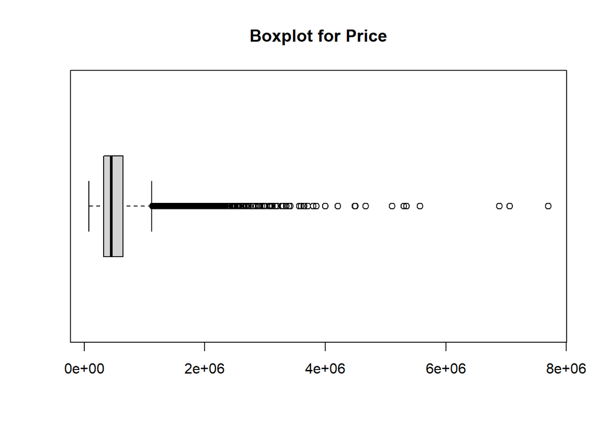

```r
# Boxplot for price
boxplot(kc_house_data$price, main = "Boxplot for Price", horizontal = TRUE)
```

```r
# Filter out extreme values
kc_house_data <- kc_house_data %>%
  filter(bedrooms <= 10, sqft_lot < quantile(sqft_lot, 0.99))

#Extracting year and month from the date column
#Grouping yr_built into decades
kc_house_data <- kc_house_data %>%
  mutate(year_sold = year(date),
         month_sold = month(date),
         decade_built = floor(yr_built / 10) * 10)
```

We filters out rows where the number of bedrooms exceeds 10; since this is an unusual case in real life. Not that we can have such a situation, but it is rare. The 99th percentile here means we exclude only the top 1% of data points. These values are often outliers that represent unusually rare lot sizes that can distort statistical analysis. By keeping 99% of the data, we retain almost all the observations while removing extreme values that may heavily influence the results.

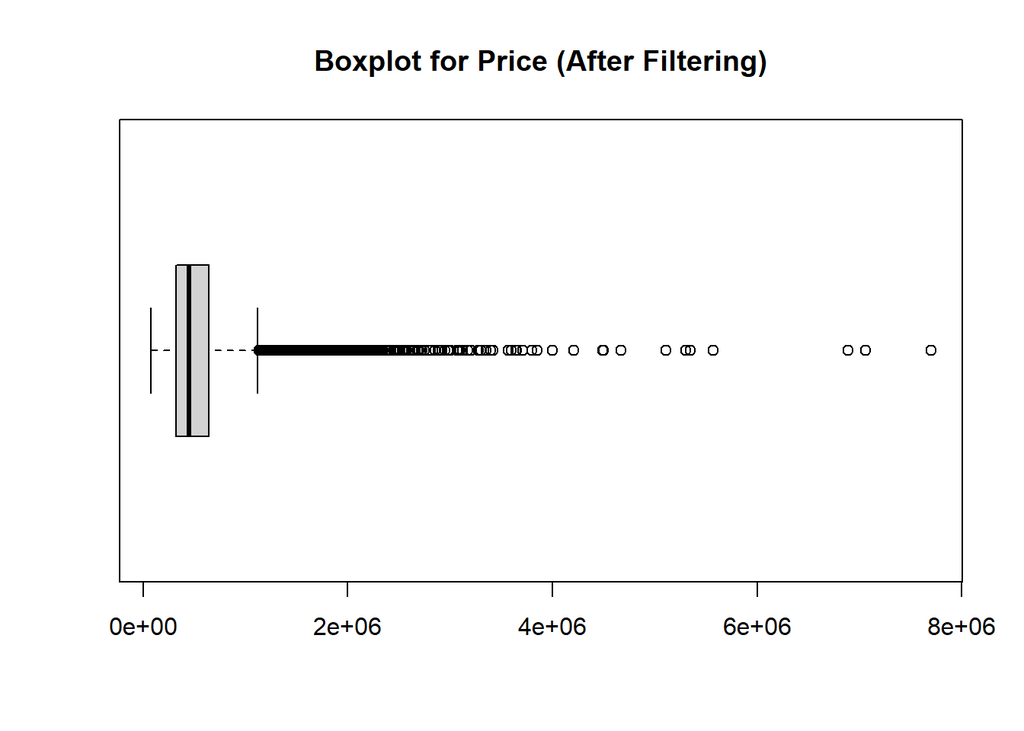

```r
# Recheck outliers after filtering
boxplot(kc_house_data$price, main = "Boxplot for Price (After Filtering)", horizontal = TRUE)
```

```r
# Correlation between sqft_lot and price
cor <- cor(kc_house_data$sqft_lot, kc_house_data$price)
cor
```

```
## [1] 0.1120719
```

The correlation between sqft_lot and price is 0.1120, thus a weak positive relationship. Given this weak positive correlation (0.1120) between sqft_lot and price, filtering based on sqft_lot does not significantly impact outliers in price. This is the reason why the boxplots for price displayed above remain unchanged even after filtering.

```r
# Calculate IQR for price
Q1 <- quantile(kc_house_data$price, 0.25)
Q3 <- quantile(kc_house_data$price, 0.75)
IQR <- Q3 - Q1

# Define lower and upper bounds for price
lower_bound <- Q1 - 1.5 * IQR
upper_bound <- Q3 + 1.5 * IQR

# Filter rows within bounds
kc_house_data <- kc_house_data %>%
  filter(price >= lower_bound & price <= upper_bound)
```

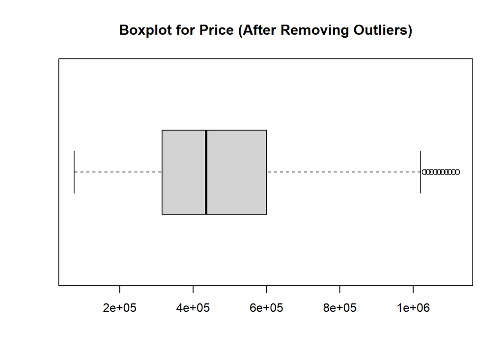

```r
# Recheck boxplot for price
boxplot(kc_house_data$price, main = "Boxplot for Price (After Removing Outliers)", horizontal = TRUE)
```

The IQR method is a common approach for dealing with outliers. It is not sufficient for this dataset due to the large range and skewness of price. The price variable is heavily skewed,hence we apply a log transformation to stabilize the variability and make the distribution more symmetric.

# Exploratory Data Analysis

```r
summary(kc_house_data$price)
```

```
##    Min. 1st Qu.  Median    Mean 3rd Qu.    Max.
##   75000  315000  435000  475560  600000 1120000
```

```r
summary(kc_house_data$sqft_living)
```

```
##    Min. 1st Qu.  Median    Mean 3rd Qu.    Max.
##     290    1400    1850    1969    2430    7480
```

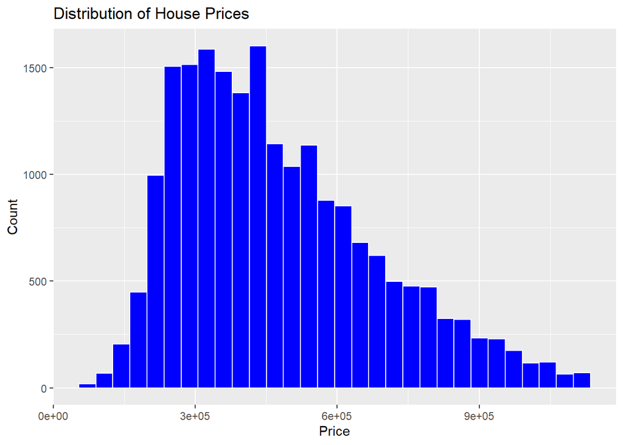

```r
ggplot(kc_house_data, aes(x = price)) +
  geom_histogram(bins = 30, fill = "blue", color = "white") +
  labs(title = "Distribution of House Prices", x = "Price", y = "Count")
```

The histogram above illustrates the distribution of house prices in King County. The distribution is right-skewed, with the majority of houses priced below $500,000. This suggests that most properties fall within a mid-range price category, while fewer properties are available at higher price points, with a long tail extending towards more expensive homes.

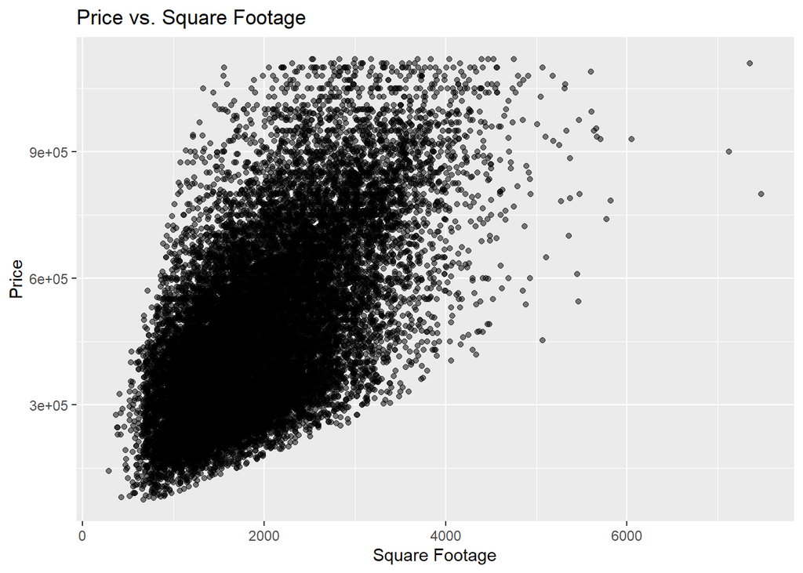

```r
ggplot(kc_house_data, aes(x = sqft_living, y = price)) +
  geom_point(alpha = 0.5) +
  labs(title = "Price vs. Square Footage", x = "Square Footage", y = "Price")
```

The scatterplot shows the relationship between house prices and square footage in King County. There is a clear positive correlation, as larger houses (in terms of square footage) tend to have higher prices. However, the relationship is not perfectly linear, with some variability in price for houses with similar square footage, likely due to other influencing factors such as location, condition, or additional features. The plot also shows a few outliers where properties with extremely high square footage or price deviate significantly from the general trend.

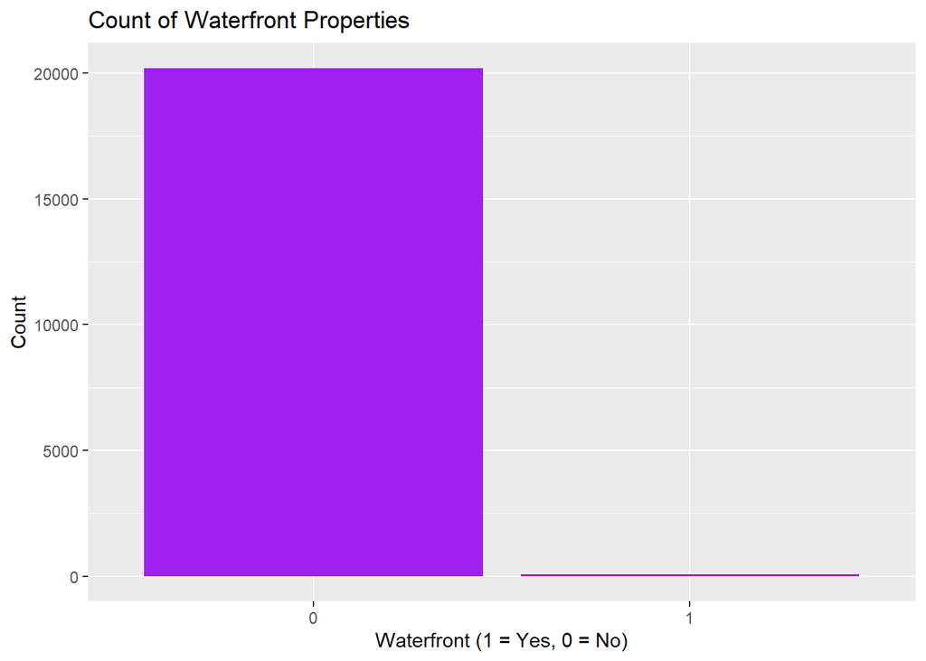

```r
ggplot(kc_house_data, aes(x = as.factor(waterfront))) +
  geom_bar(fill = "purple") +
  labs(title = "Count of Waterfront Properties", x = "Waterfront (1 = Yes, 0 = No)", y = "Count")
```

The bar chart illustrates the distribution of waterfront properties in the dataset. It shows that the majority of houses in King County do not have waterfront access (represented by `0`), while a very small fraction of houses are located on waterfronts (represented by `1`).

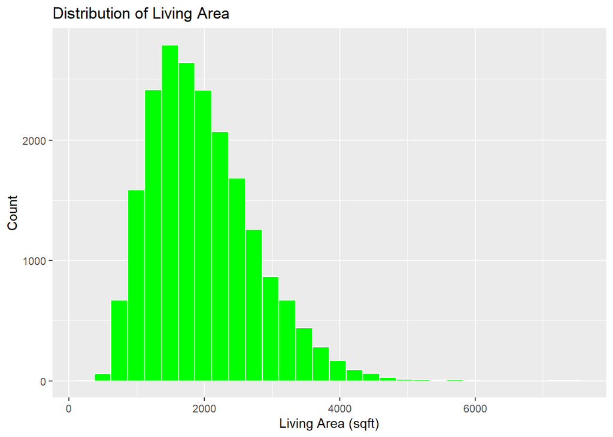

```r
ggplot(kc_house_data, aes(x = sqft_living)) +
  geom_histogram(bins = 30, fill = "green", color = "white") +
  labs(title = "Distribution of Living Area", x = "Living Area (sqft)", y = "Count")
```

The histogram displays the distribution of living area (in square feet) for houses in King County. The data is slightly right-skewed, with the majority of homes having a living area between 1,000 and 3,000 square feet. A small number of houses have exceptionally large living areas, exceeding 4,000 square feet, which contribute to the skewness. This pattern highlights that most homes are of moderate size, while a few larger properties may significantly influence the mean living area.

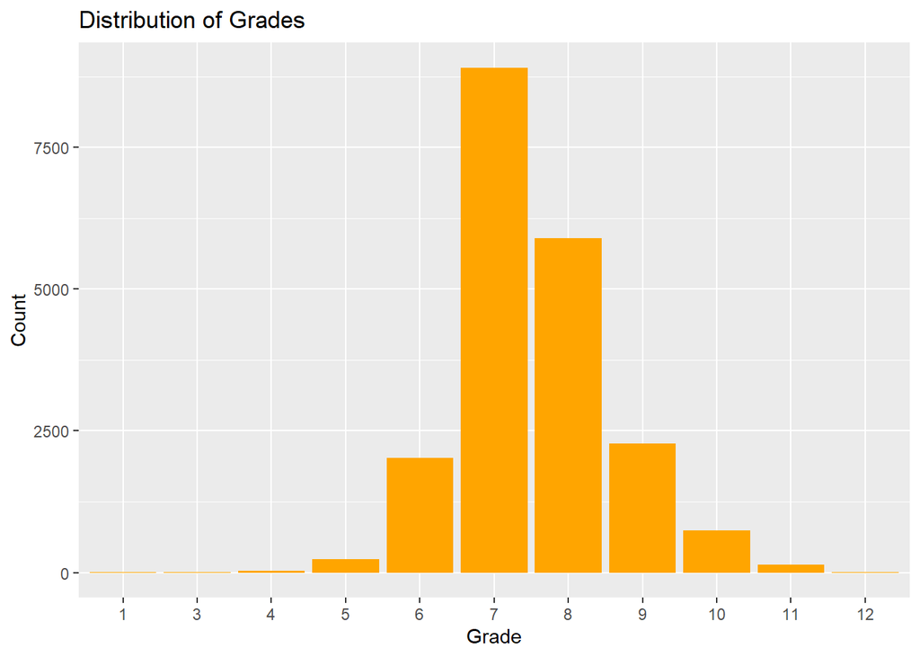

```r
ggplot(kc_house_data, aes(x = as.factor(grade))) +
  geom_bar(fill = "orange") +
  labs(title = "Distribution of Grades", x = "Grade", y = "Count")
```

The bar chart shows the distribution of house grades in King County, where grades represent the overall construction and design quality. The majority of houses are assigned grades between 7 and 8, indicating average to slightly above-average quality. Very few houses fall at the extreme ends of the scale (grades 1–5 or 10–12), highlighting that most homes in this dataset are concentrated around the mid-range of the grading system.

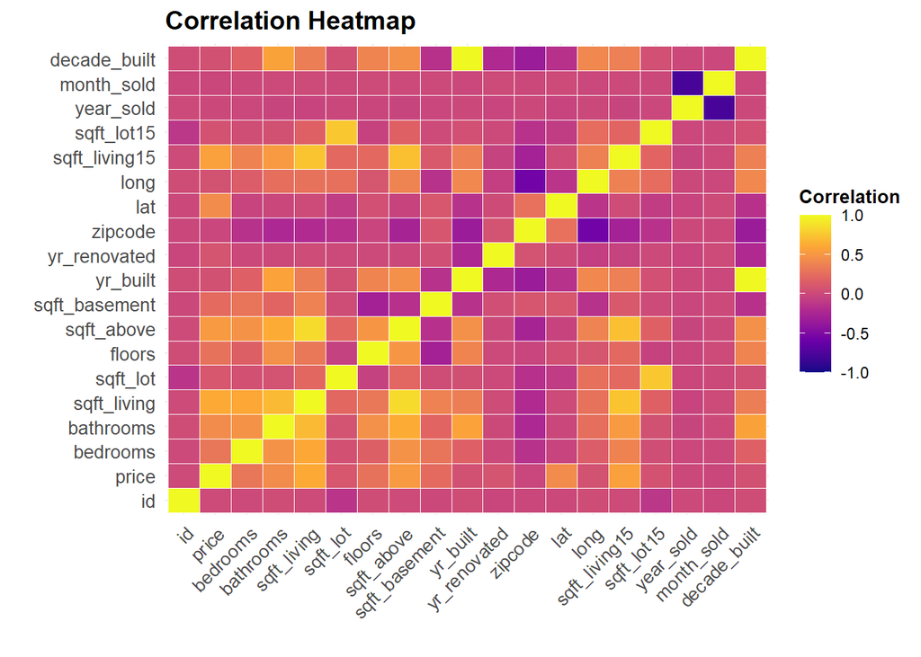

```r
kc_house_data$floors <- ceiling(kc_house_data$floors)

kc_house_data$bathrooms <- ceiling(kc_house_data$bathrooms)

kc_house_data$bedrooms<- ceiling(kc_house_data$bedrooms)

# Compute correlation matrix
cor_matrix <- cor(kc_house_data %>% select_if(is.numeric), use = "complete.obs")

# Convert correlation matrix into a tidy format using tidyr
melted_cor <- as.data.frame(as.table(cor_matrix))

# Create the heatmap with viridis colors
ggplot(data = melted_cor, aes(x = Var1, y = Var2, fill = Freq)) +
  geom_tile(color = "white") +
  scale_fill_viridis_c(option = "plasma", name = "Correlation", limits = c(-1, 1)) +
  theme_minimal() +
  theme(
    axis.text.x = element_text(angle = 45, vjust = 1, hjust = 1, size = 10),
    axis.text.y = element_text(size = 10),
    plot.title = element_text(size = 14, face = "bold"),
    legend.title = element_text(size = 10, face = "bold"),
    legend.text = element_text(size = 9)
  ) +
  labs(title = "Correlation Heatmap", x = "", y = "")
```

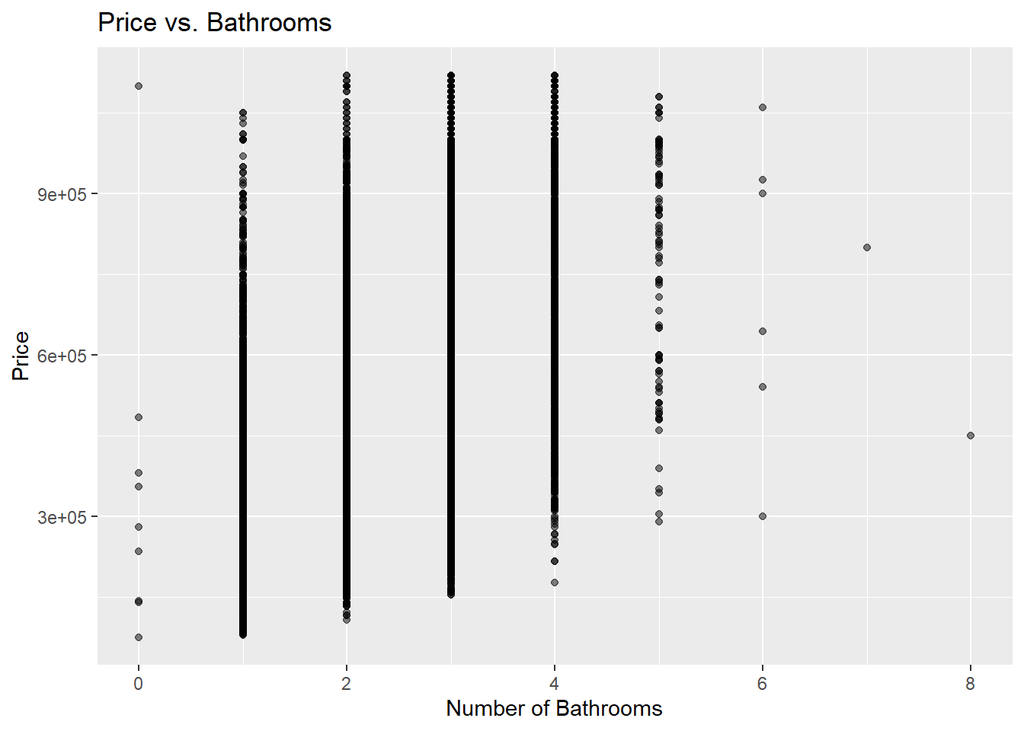

```r
ggplot(kc_house_data, aes(x = bathrooms, y = price)) +
  geom_point(alpha = 0.5) +
  labs(title = "Price vs. Bathrooms", x = "Number of Bathrooms", y = "Price")
```

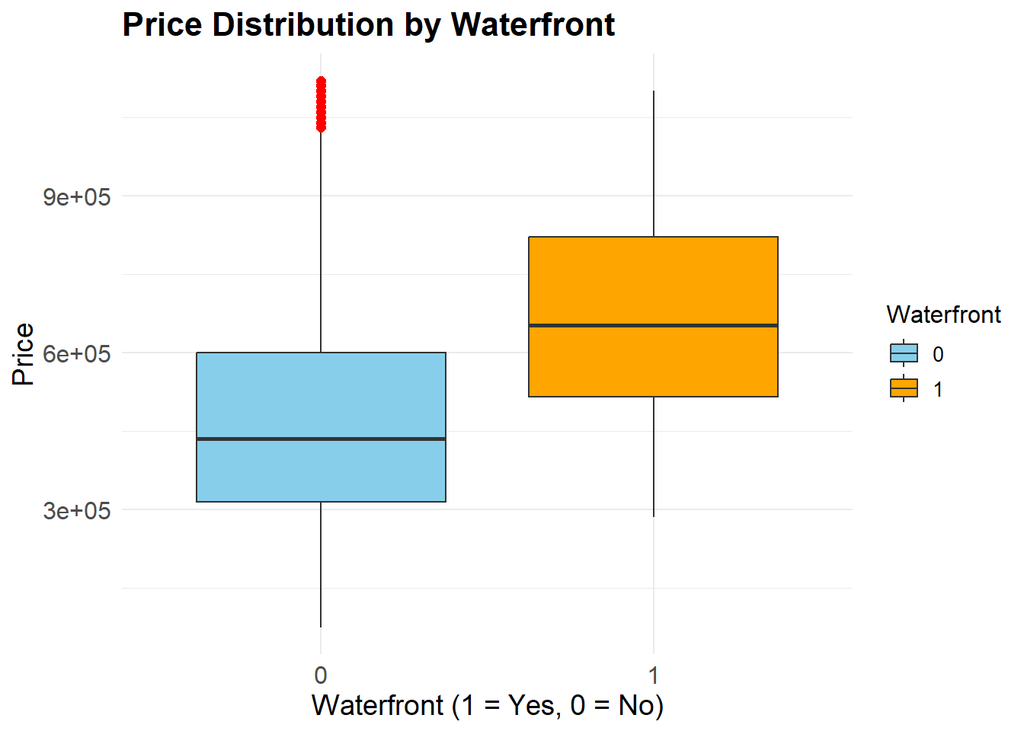

```r
ggplot(kc_house_data, aes(x = as.factor(waterfront), y = price, fill = as.factor(waterfront))) +
  geom_boxplot(outlier.color = "red", outlier.size = 2) +  # Customize outliers
  scale_fill_manual(values = c("skyblue", "orange")) +     # Add custom colors
  labs(
    title = "Price Distribution by Waterfront",
    x = "Waterfront (1 = Yes, 0 = No)",
    y = "Price",
    fill = "Waterfront"
  ) +
  theme_minimal() +
  theme(
    plot.title = element_text(size = 16, face = "bold"),
    axis.text = element_text(size = 12),
    axis.title = element_text(size = 14),
    legend.title = element_text(size = 12),
    legend.text = element_text(size = 10)
  )
```

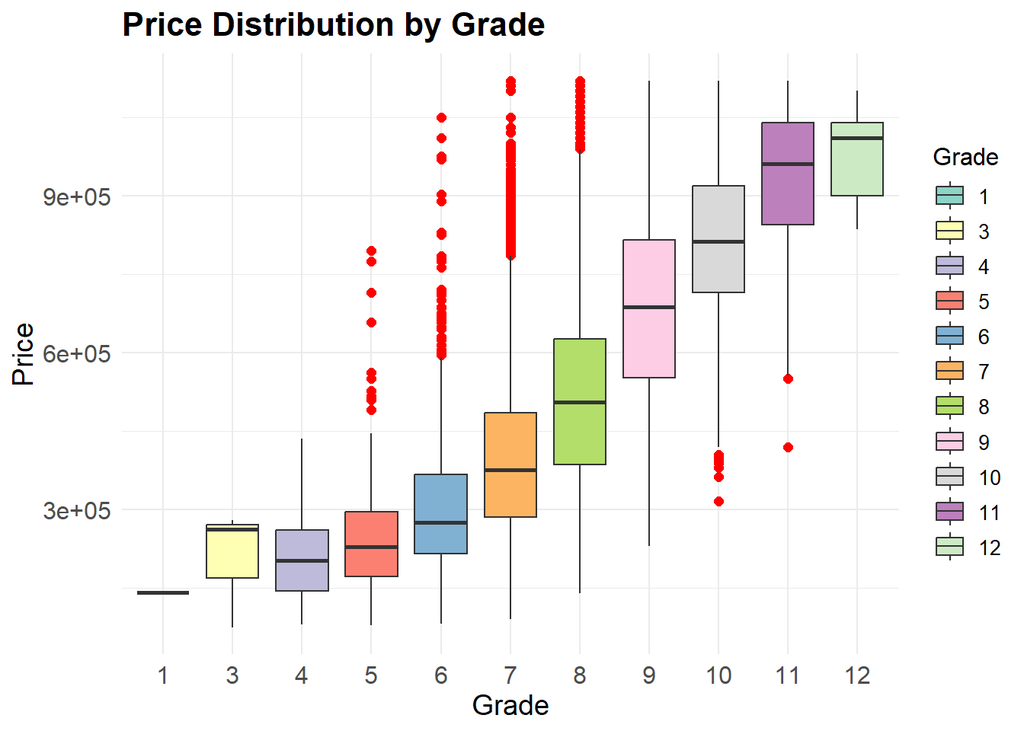

```r
ggplot(kc_house_data, aes(x = as.factor(grade), y = price, fill = as.factor(grade))) +
  geom_boxplot(outlier.color = "red", outlier.size = 2) +  # Customize outliers
  scale_fill_brewer(palette = "Set3") +                   # Use a predefined color palette
  labs(
    title = "Price Distribution by Grade",
    x = "Grade",
    y = "Price",
    fill = "Grade"
  ) +
  theme_minimal() +
  theme(
    plot.title = element_text(size = 16, face = "bold"),
    axis.text = element_text(size = 12),
    axis.title = element_text(size = 14),
    legend.title = element_text(size = 12),
    legend.text = element_text(size = 10)
  )
```

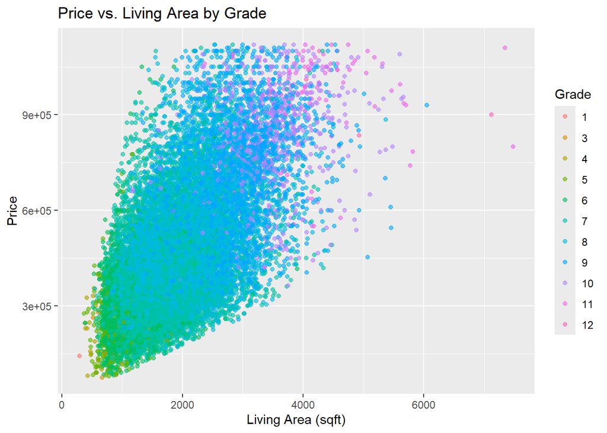

```r
ggplot(kc_house_data, aes(x = sqft_living, y = price, color = as.factor(grade))) +
  geom_point(alpha = 0.6) +
  labs(title = "Price vs. Living Area by Grade", x = "Living Area (sqft)", y = "Price", color = "Grade")
```

The scatterplot illustrates the relationship between house prices and living area, with points color-coded by grade (quality of construction). There is a clear positive trend, where houses with larger living areas generally have higher prices. Additionally, higher-grade houses tend to cluster toward the upper end of both price and living area, indicating that grade amplifies the effect of living area on price. Lower-grade homes are concentrated in the lower price and living area range, while higher-grade homes span a broader range of living areas, reflecting their premium quality. This plot highlights the combined impact of living area and grade on house prices.

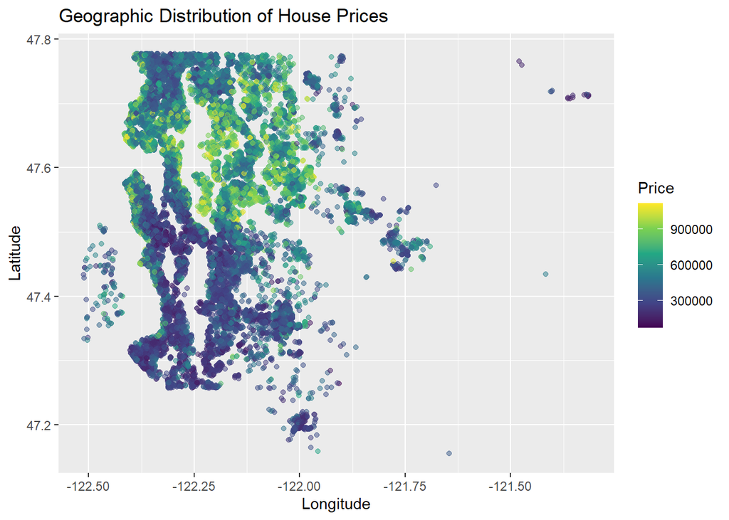

```r
ggplot(kc_house_data, aes(x = long, y = lat, color = price)) +
  geom_point(alpha = 0.5) +
  scale_color_viridis_c() +
  labs(title = "Geographic Distribution of House Prices", x = "Longitude", y = "Latitude", color = "Price")
```

The scatterplot maps the geographic distribution of house prices based on latitude and longitude. The color gradient represents house prices, with purple indicating lower prices and yellow indicating higher prices. Higher-priced homes are concentrated in specific areas, likely reflecting desirable neighborhoods or proximity to amenities such as waterfronts or urban centers. In contrast, lower-priced homes are more dispersed. This spatial pattern highlights the importance of location in determining house prices, demonstrating significant geographic variability within King County. The clustering of high-priced properties suggests localized demand for premium homes.

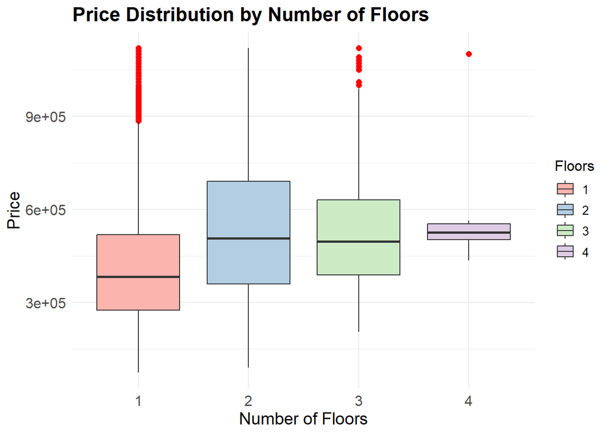

```r
ggplot(kc_house_data, aes(x = as.factor(floors), y = price, fill = as.factor(floors))) +
  geom_boxplot(outlier.color = "red", outlier.size = 2) +
  scale_fill_brewer(palette = "Pastel1") +
  labs(
    title = "Price Distribution by Number of Floors",
    x = "Number of Floors",
    y = "Price",
    fill = "Floors"
  ) +
  theme_minimal() +
  theme(
    plot.title = element_text(size = 16, face = "bold"),
    axis.text = element_text(size = 12),
    axis.title = element_text(size = 14),
    legend.title = element_text(size = 12),
    legend.text = element_text(size = 10)
  )
```

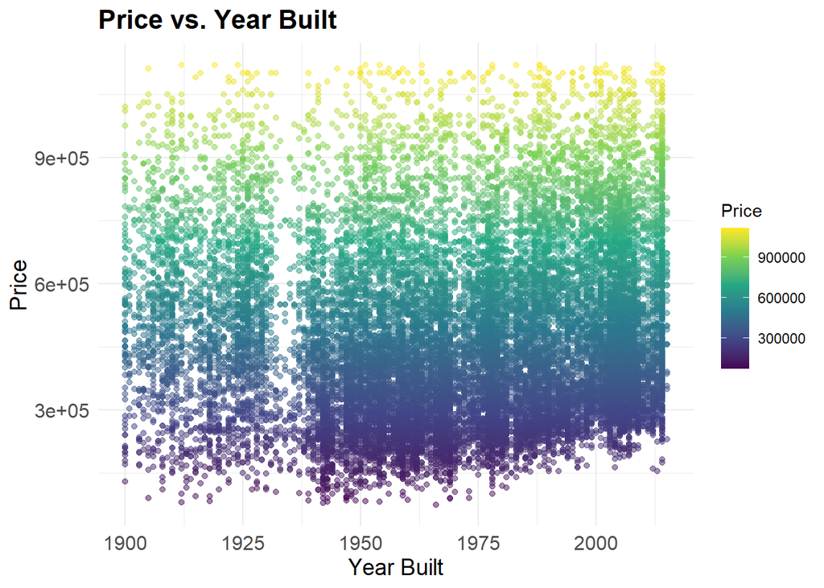

```r
ggplot(kc_house_data, aes(x = yr_built, y = price, color = price)) +
  geom_point(alpha = 0.5) +
  scale_color_viridis_c() +
  labs(
    title = "Price vs. Year Built",
    x = "Year Built",
    y = "Price",
    color = "Price"
  ) +
  theme_minimal() +
  theme(
    plot.title = element_text(size = 16, face = "bold"),
    axis.text = element_text(size = 12),
    axis.title = element_text(size = 14)
  )
```

The scatterplot demonstrates the relationship between house prices and the year the house was built. The color gradient represents price levels, with yellow indicating higher-priced properties. Houses built in recent years (after 2000) show a tendency for higher prices compared to older homes. However, there is a considerable overlap in prices across years, suggesting that factors other than the year built, may play a more significant role in determining house prices.

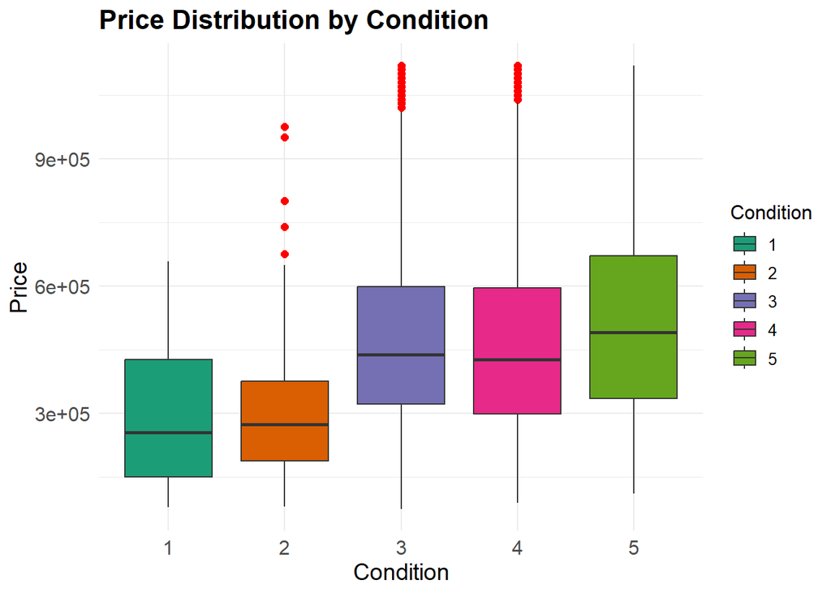

```r
ggplot(kc_house_data, aes(x = as.factor(condition), y = price, fill = as.factor(condition))) +
  geom_boxplot(outlier.color = "red", outlier.size = 2) +
  scale_fill_brewer(palette = "Dark2") +
  labs(
    title = "Price Distribution by Condition",
    x = "Condition",
    y = "Price",
    fill = "Condition"
  ) +
  theme_minimal() +
  theme(
    plot.title = element_text(size = 16, face = "bold"),
    axis.text = element_text(size = 12),
    axis.title = element_text(size = 14),
    legend.title = element_text(size = 12),
    legend.text = element_text(size = 10)
  )
```

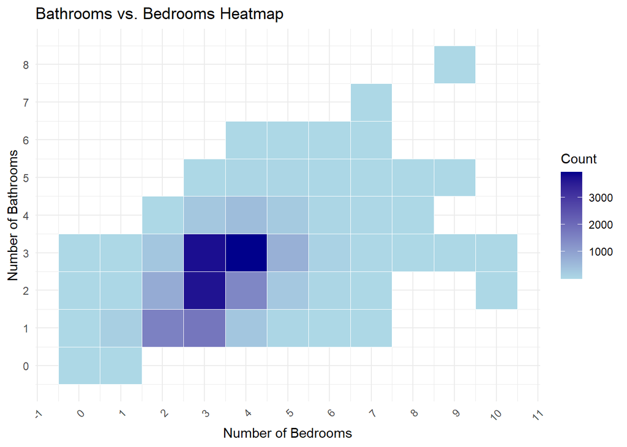

```r
kc_house_data %>%
  group_by(bedrooms, bathrooms) %>%
  summarise(count = n()) %>%
  ggplot(aes(x = as.integer(bedrooms), y = as.integer(bathrooms), fill = count)) +  # Convert to integers
  geom_tile(color = "white") +
  scale_fill_gradient(low = "lightblue", high = "darkblue", name = "Count") +
  scale_x_continuous(breaks = scales::breaks_pretty(n = 10)) +  # Ensure only integer labels
  scale_y_continuous(breaks = scales::breaks_pretty(n = 10)) +
  labs(title = "Bathrooms vs. Bedrooms Heatmap", x = "Number of Bedrooms", y = "Number of Bathrooms") +
  theme_minimal() +
  theme(axis.text.x = element_text(angle = 45, hjust = 1))
```

The heatmap illustrates the distribution of houses based on the number of bedrooms and bathrooms, with darker shades indicating higher counts. The most common configurations are houses with 3 to 4 bedrooms and 2 to 3 bathrooms, as reflected by the darkest blue region. Houses with fewer or more bedrooms and bathrooms are less frequent, as indicated by the lighter shades in other areas of the heatmap.This trend suggests that the dataset is dominated by mid-sized homes, which likely cater to average family sizes.

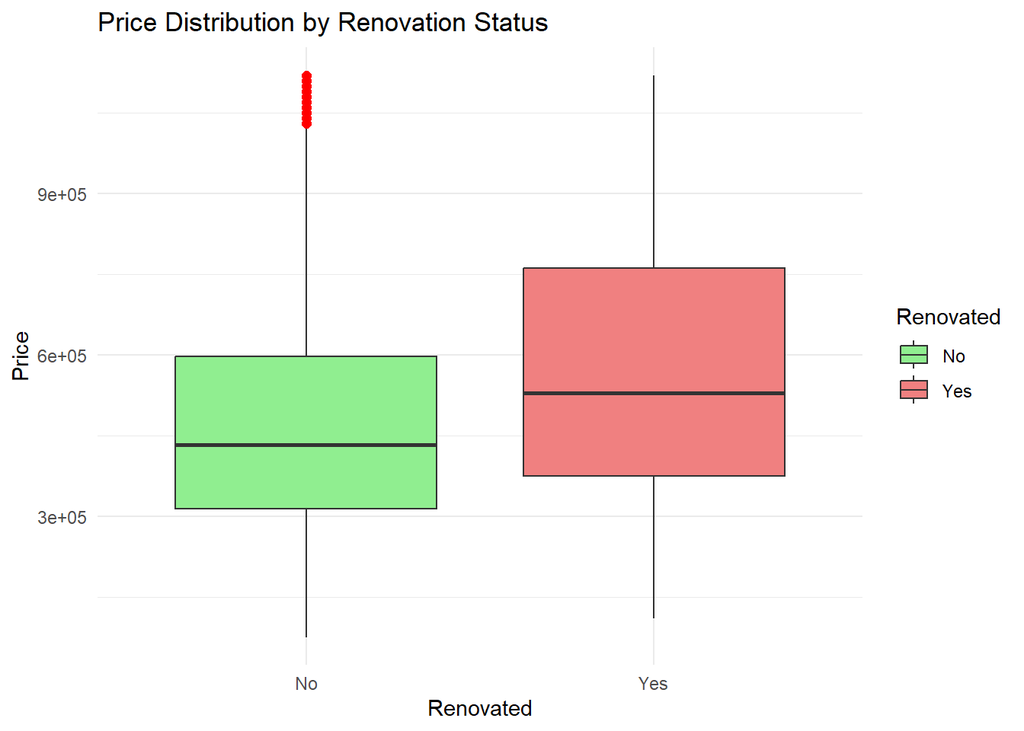

```r
# Renovated vs. Non-Renovated Boxplot
kc_house_data %>%
  mutate(renovated = ifelse(yr_renovated > 0, "Yes", "No")) %>%
  ggplot(aes(x = renovated, y = price, fill = renovated)) +
  geom_boxplot(outlier.color = "red", outlier.size = 2) +
  scale_fill_manual(values = c("lightgreen", "lightcoral")) +
  labs(title = "Price Distribution by Renovation Status", x = "Renovated", y = "Price", fill = "Renovated") +
  theme_minimal()
```

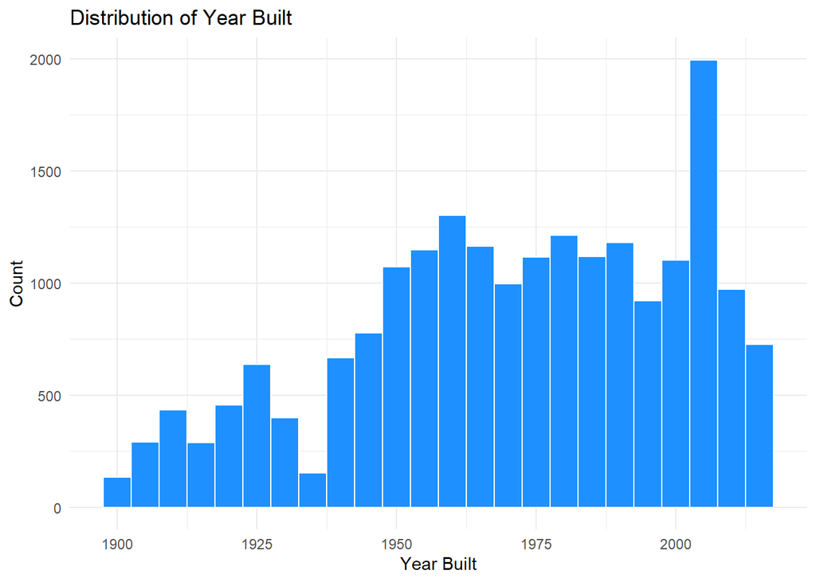

```r
# Year Built Histogram
ggplot(kc_house_data, aes(x = yr_built)) +
  geom_histogram(binwidth = 5, fill = "dodgerblue", color = "white") +
  labs(title = "Distribution of Year Built", x = "Year Built", y = "Count") +
  theme_minimal()
```

The histogram displays the distribution of houses by the year they were built. There is a noticeable increase in the number of houses constructed from the mid-20th century, peaking around the early 2000s, likely reflecting housing market booms. Construction activity is lower for homes built before 1925 and after 2010, suggesting that newer constructions are relatively rare in the dataset. This distribution provides insights into the age of the housing stock in the dataset, with most houses built between 1950 and 2000.